# Analyses of Variance (ANOVA)

Adam Raikes

March 13, 2017

# Purpose

The purpose of this slideshow is to discuss ANOVAs. An ANOVA is a powerful generalization of the two-sample T-test which simultaneously tests differences between multiple groups.

# ANOVA

ANOVAs are based on the F-distribution. Like t-tests, the shape and taper of the distribution is dependent on the number of degrees of freedom existent in the data. These degrees of freedom will be discussed in more detail later.

# F distribution

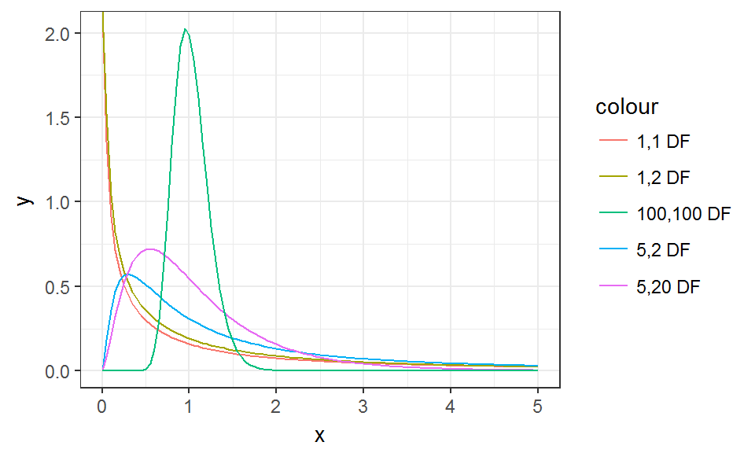

# ANOVA general form

An ANOVA can be thought of as a linear equation. For a comparison of one **thing** comprised of four groups, this equation is generally:

$\hat{Y}_{ij} = \mu + X_i + \epsilon_j$

This is called a one-way ANOVA.

# ANOVA general form

The if we were to consider categorical classifications that may interact with each other, then the general form is:

$\hat{Y}_{ijk} = \mu + X_{1i} + X_{2j} + X_{3ij} + \epsilon_k$

This is called a two-way ANOVA

# ANOVA assumptions

When working with ANOVAs, there are assumptions that must be met.

- Random sampling from a defined population
- **Independent** observations
- Homogeneity of variances
- The residuals ($\epsilon$s) are approximately normally distributed
- Equal sample sizes

# ANOVA hypotheses

Recall that we must set our null and alternative hypothesis.

$H_0: \mu_1 = \mu_2 = \mu_3 = \ldots$

$H_A:$ There is an inequality somewhere.

# ANOVA computation

So how do we compute an ANOVA? Broadly:

$F = \frac{MSR}{MSE}$

where MSR is the mean square for the treatments/categorical variables and MSE is the mean square error (the $\epsilon$s)

# ANOVA computation

So how do we compute an ANOVA? See the board and take notes.

# How does this look

We’re going to use data from a publicly available health survey dataset.

```
## # A tibble: 6 × 76
##      ID SurveyYr Gender   Age AgeDecade AgeMonths  Race1  Race3
##   <int>   <fctr> <fctr> <int>    <fctr>     <int> <fctr> <fctr>
## 1 51624  2009_10   male    34     30-39       409  White     NA
## 2 51624  2009_10   male    34     30-39       409  White     NA
## 3 51624  2009_10   male    34     30-39       409  White     NA
## 4 51625  2009_10   male     4       0-9        49  Other     NA
## 5 51630  2009_10 female    49     40-49       596  White     NA
## 6 51638  2009_10   male     9       0-9       115  White     NA
## # ... with 68 more variables: Education <fctr>, MaritalStatus <fctr>,
## #   HHIncome <fctr>, HHIncomeMid <int>, Poverty <dbl>, HomeRooms <int>,
## #   HomeOwn <fctr>, Work <fctr>, Weight <dbl>, Length <dbl>,
## #   HeadCirc <dbl>, Height <dbl>, BMI <dbl>, BMICatUnder20yrs <fctr>,
## #   BMI_WHO <fctr>, Pulse <int>, BPSysAve <int>, BPDiaAve <int>,
## #   BPSys1 <int>, BPDia1 <int>, BPSys2 <int>, BPDia2 <int>, BPSys3 <int>,
## #   BPDia3 <int>, Testosterone <dbl>, DirectChol <dbl>, TotChol <dbl>,
## #   UrineVol1 <int>, UrineFlow1 <dbl>, UrineVol2 <int>, UrineFlow2 <dbl>,
## #   Diabetes <fctr>, DiabetesAge <int>, HealthGen <fctr>,
## #   DaysPhysHlthBad <int>, DaysMentHlthBad <int>, LittleInterest <fctr>,
## #   Depressed <fctr>, nPregnancies <int>, nBabies <int>, Age1stBaby <int>,
## #   SleepHrsNight <int>, SleepTrouble <fctr>, PhysActive <fctr>,
## #   PhysActiveDays <int>, TVHrsDay <fctr>, CompHrsDay <fctr>,
## #   TVHrsDayChild <int>, CompHrsDayChild <int>, Alcohol12PlusYr <fctr>,
## #   AlcoholDay <int>, AlcoholYear <int>, SmokeNow <fctr>, Smoke100 <fctr>,
## #   Smoke100n <fctr>, SmokeAge <int>, Marijuana <fctr>,
## #   AgeFirstMarij <int>, RegularMarij <fctr>, AgeRegMarij <int>,
## #   HardDrugs <fctr>, SexEver <fctr>, SexAge <int>, SexNumPartnLife <int>,
## #   SexNumPartYear <int>, SameSex <fctr>, SexOrientation <fctr>,
## #   PregnantNow <fctr>
```

# Gender, Race, and BMI

So we are going to look at weight between genders and races.

```r
table(NHANES$Gender, NHANES$Race1)
```

```
##
##          Black Hispanic Mexican White Other
##   female   614      320     452  3221   413
##   male     583      290     563  3151   393
```

# Gender, Race, and BMI

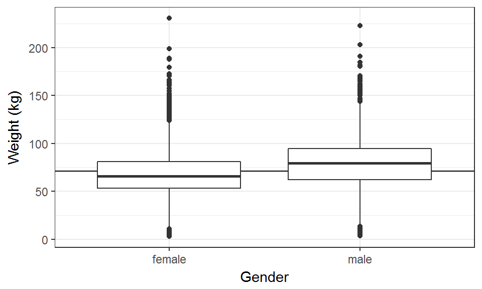

# Gender, Race, and BMI

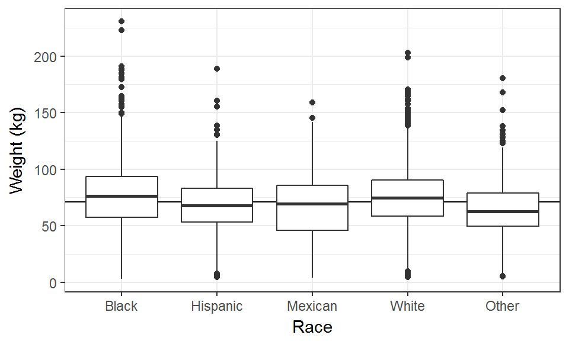

# Gender, Race, and BMI

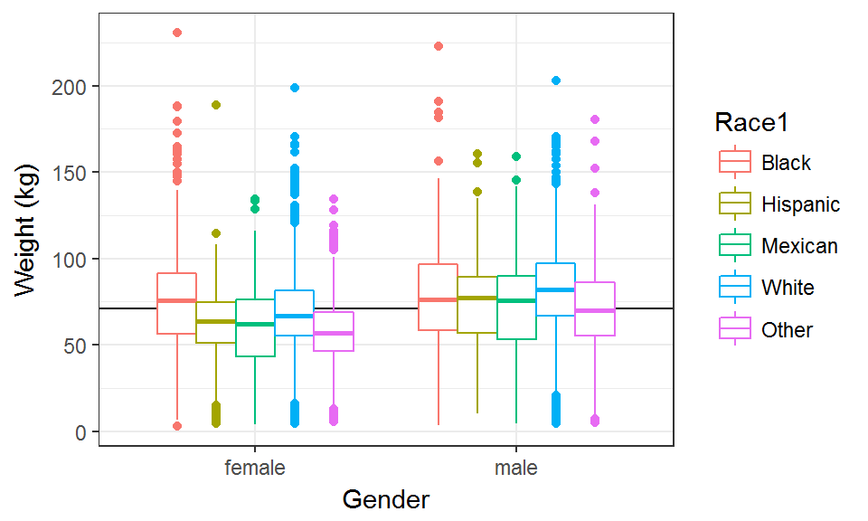

# Gender, Race, and BMI

Because there are only two levels of gender, we can use a T-test

```r
t.test(Weight ~ Gender, data = NHANES)
```

```
##
##  Welch Two Sample t-test
##
## data:  Weight by Gender
## t = -16.604, df = 9693, p-value < 2.2e-16
## alternative hypothesis: true difference in means is not equal to 0
## 95 percent confidence interval:
##  -10.714821  -8.452043
## sample estimates:
## mean in group female   mean in group male
##             66.20843             75.79187
```

# Gender, Race, and BMI

We can also do it as an ANOVA:

$\hat{Weight}_{ij} = \mu + {Gender}_i + \epsilon_j$

```r
summary(aov(Weight ~ Gender, data = NHANES))
```

```
##               Df  Sum Sq Mean Sq F value Pr(>F)
## Gender         1  227811  227811     276 <2e-16 ***
## Residuals   9920 8188039     825
## ---
## Signif. codes:  0 '***' 0.001 '**' 0.01 '*' 0.05 '.' 0.1 ' ' 1
## 78 observations deleted due to missingness
```